# Final

Sean Fahey

2023-04-23

# About the Dataset

### Reference

**[Soil Dataset](https://www.kaggle.com/datasets/ramakrishnanthiyagu/soil-compositions)**

Originally distributed by LSU School of Plant, Environmental, and Soil Sciences (Dr. Moser Research Laboratory).

### Description

**Summary:**

Soil samples in “commerce silt loam” cotton fields in Louisiana collected between 1987 and 1990.

9 response variables were measured at 4 different depths (0-10 cm, 10-30 cm, 30-60 cm, and 60-90 cm), and 3 different contours (Top, Slope, and Depression).

**Response Variables:**

- pH
- N (total Nitrogen %)
- Dens (soil density in gm/cm^3)
- P (total Phosphorous in ppm)
- Ca (total Calcium in meq/100g)
- Mg (total Magnesium in meq/100g)
- K (total Potassium in meq/100g)
- Na (total Sodium in meq/100g)
- Conduc (conductivity)

```r
# Import data csv file
soil = read.csv("Soils.csv")
head(soil)
```

```
##   Group Contour  Depth Gp Block   pH     N Dens   P    Ca   Mg    K   Na Conduc
## 1     1     Top   0-10 T0     1 5.40 0.188 0.92 215 16.35 7.65 0.72 1.14   1.09
## 2     1     Top   0-10 T0     2 5.65 0.165 1.04 208 12.25 5.15 0.71 0.94   1.35
## 3     1     Top   0-10 T0     3 5.14 0.260 0.95 300 13.02 5.68 0.68 0.60   1.41
## 4     1     Top   0-10 T0     4 5.14 0.169 1.10 248 11.92 7.88 1.09 1.01   1.64
## 5     2     Top Oct-30 T1     1 5.14 0.164 1.12 174 14.17 8.12 0.70 2.17   1.85
## 6     2     Top Oct-30 T1     2 5.10 0.094 1.22 129  8.55 6.92 0.81 2.67   3.18
```

```r
# Correct the string entries for Depth
soil$Depth[soil$Depth == "0-10"] = "Shallow"
soil$Depth[soil$Depth == "Oct-30"] = "Medium"
soil$Depth[soil$Depth == "30-60"] = "Deep"
soil$Depth[soil$Depth == "60-90"] = "Very Deep"

# convert depth to an ordered factor
soil$Depth = factor(
    soil$Depth,
    ordered = TRUE,
    levels = c("Shallow", "Medium", "Deep", "Very Deep")
  )

# convert Contour to a factor
soil$Contour = as.factor(soil$Contour)

# Add a group column to the front by combining Depth and Contour columns
group <- paste(soil$Depth, soil$Contour, sep="_")
soil = data.frame(Group = as.factor(group), soil)

# Drop unused columns
soil = subset(soil, select = -c(Group.1, Gp, Block))
```

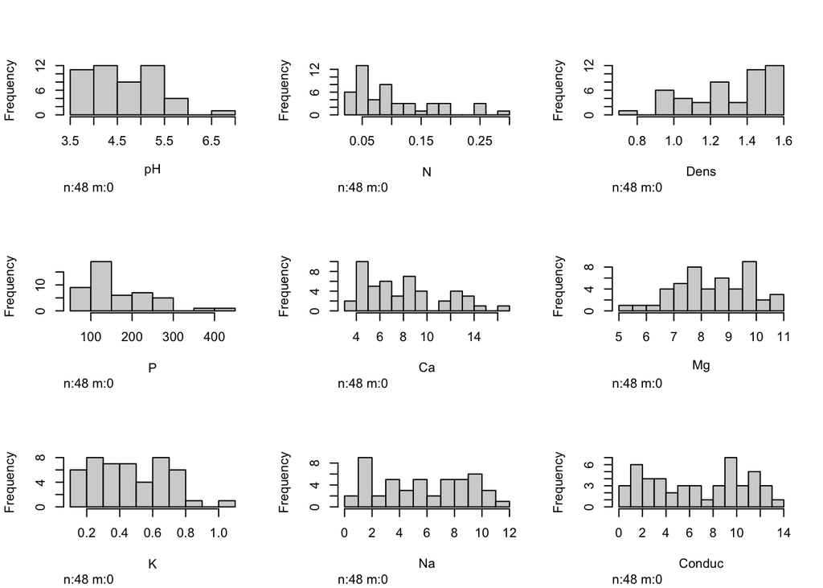

```r
hist.data.frame(soil[4:12], nclass=10, na.big=TRUE)
```

```r
dev.print(pdf, 'histograms.pdf')
```

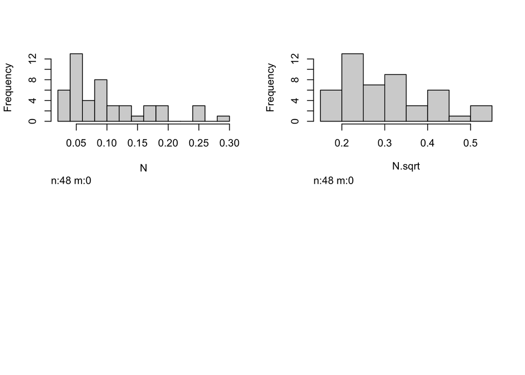

```r
soil$N.sqrt = sqrt(soil$N)
hist.data.frame(soil[c('N', 'N.sqrt')], nclass=10)
```

```r
dev.print(pdf, 'N-transformation.pdf')
```

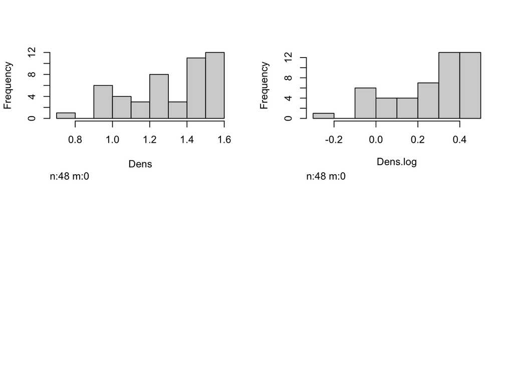

```r
soil$Dens.log = log(soil$Dens)
hist.data.frame(soil[c('Dens', 'Dens.log')], nclass=10)
```

```r
dev.print(pdf, 'Dens-transformation.pdf')
```

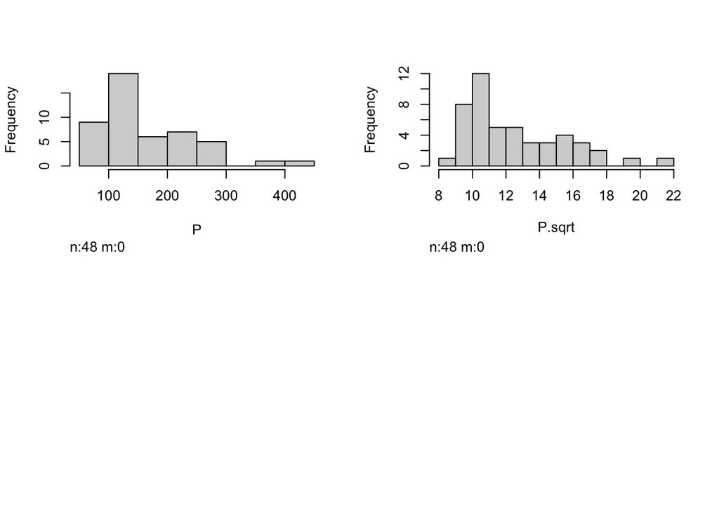

```r
soil$P.sqrt = sqrt(soil$P)
hist.data.frame(soil[c('P', 'P.sqrt')], nclass=10)
```

```r
dev.print(pdf, 'P-transformation.pdf')
```

```r
soil = subset(soil, select = -c(N, Dens.log, P.sqrt))
```

NMDS run for all values of K 1 through 10. This is done to check what number of dimensions is best to use for analysis. The number of dimensions is decided by stress level, with a stress of <0.05 considered to be very good.

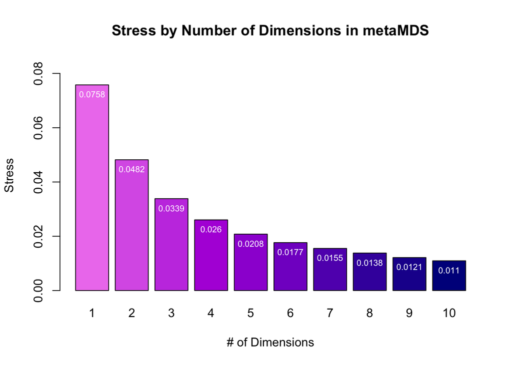

```r
n = 10
stress <- vector(length = n)
for (i in 1:n) { # loop through values of i 1 through 10
    stress[i] <- metaMDS(
  comm = subset(soil, select = -c(Group, Contour, Depth)),
  distance = "bray",
  k = i, # set k to the looped value
  trace = 0)$stress
}

# assign names to the stress vector (values 1 through 10)
names(stress) <- paste0(1:n)

# bar plot for stress vector
bp = barplot(
  stress,
  ylab = "Stress",
  xlab = "# of Dimensions",
  main='Stress by Number of Dimensions in metaMDS', # title
  las = 0,

  # y axis scale. Default was causing the highest bar to clip into the title.
  ylim = c(0, 0.085),
  col = colorRampPalette( # color range for the bars
    colors = c(
      "violet",
      "darkviolet",
      "darkblue"
      ))(10),
  )

# add text labels to each bar
text(
  bp,
  stress, # stress vector is used to mark points where text will appear
  round(stress, 4), # text to display
  pos=1, # pos=1 means just below the point
  cex = 0.7, # scale to 70%
  col="white"
  )
```

```r
dev.print(pdf, 'stress-per-dim.pdf')
```

```r
soil.nmds = metaMDS(
  comm = subset(soil, select = -c(Group, Contour, Depth)),
  distance = "bray", # using bray curtis dissimilarity
  k = 2,
  trace = 0
  )
```

```r
soil.nmds
```

```
##
## Call:
## metaMDS(comm = subset(soil, select = -c(Group, Contour, Depth)),      distance = "bray", k = 2, trace = 0)
##
## global Multidimensional Scaling using monoMDS
##
## Data:     wisconsin(sqrt(subset(soil, select = -c(Group, Contour, Depth))))
## Distance: bray
##
## Dimensions: 2
## Stress:     0.04818374
## Stress type 1, weak ties
## Best solution was not repeated after 20 tries
## The best solution was from try 0 (metric scaling or null solution)
## Scaling: centring, PC rotation, halfchange scaling
## Species: expanded scores based on 'wisconsin(sqrt(subset(soil, select = -c(Group, Contour, Depth))))'
```

Stress of 0.0482 is considered very good.

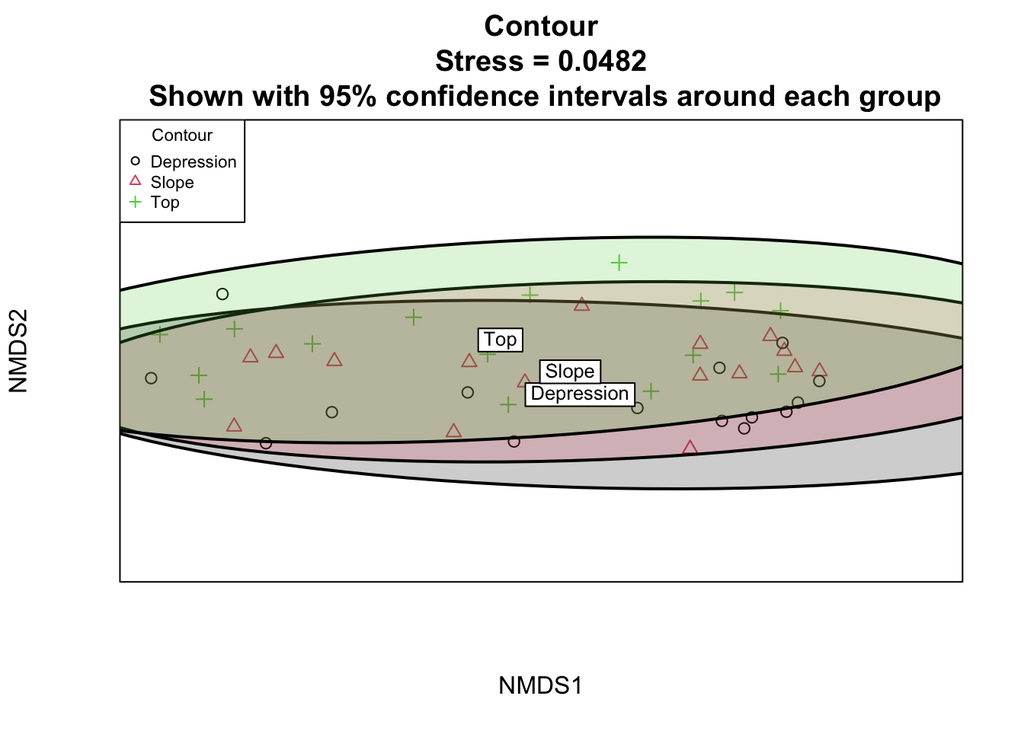

```r
soil.ord = ordiplot(
  soil.nmds,
  type = 'none',
  main = paste0( # plot title
    'Contour\nStress = ',
    round(soil.nmds$stress,dig=4), # add stress label to title
    '\n Shown with 95% confidence intervals around each group'
    ),
  xaxt = 'none', # remove tick marks from NMDS plots
  yaxt = 'none'
  #cex.main=2,
  #cex.lab=1.3
  )

?ordiplot

points(
  soil.ord,
  what = 'sites',
  col = as.numeric(soil$Contour), # color by habitat
  pch = as.numeric(soil$Contour), # shape by habitat
  )

legend( # add legend at bottom left
  'topleft',
  legend = levels(soil$Contour),
  col = 1:4, # make the colors match the points
  pch = 1:4, # make the shapes match
  cex = .7,
  title = "Contour"
  )

ordiellipse(
  soil.nmds,
  kind = 'sd',
  draw = "polygon",
  col = 1:4,
  alpha = 0.2,
  groups = soil$Contour,
  label = TRUE,
  border = NULL,
  conf = 0.95,
  lwd = 2
  )
```

```r
dev.print(pdf, 'ordination-contour.pdf')
```

Contour groups show no discernible differentiation between the 95% confidence ellipses.

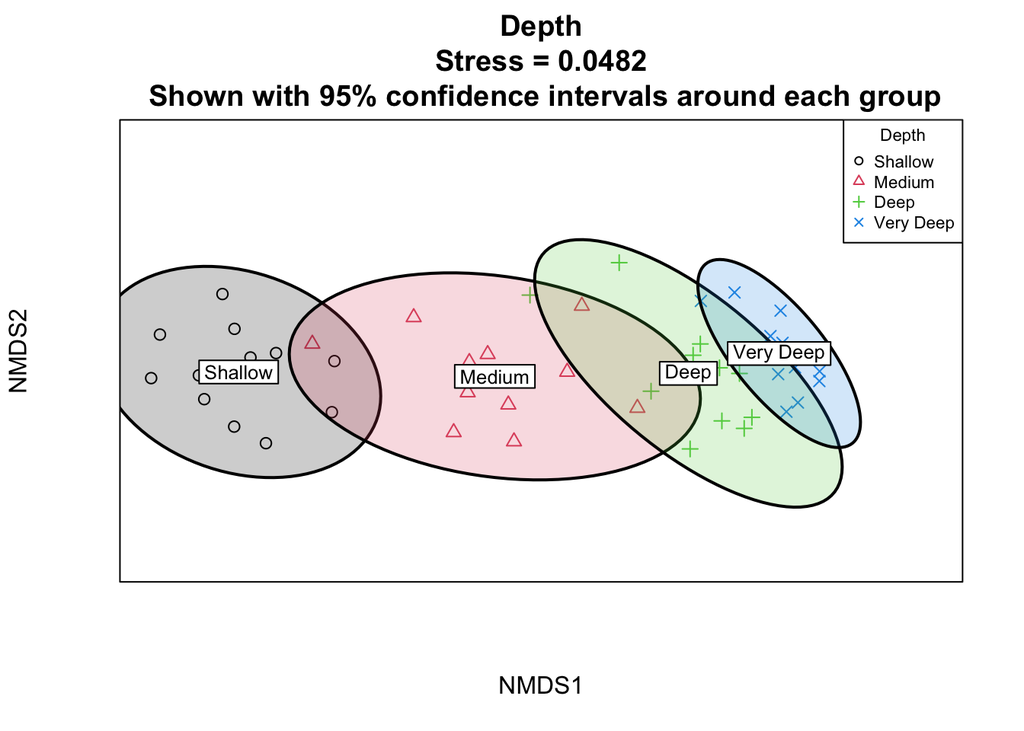

```r
soil.ord = ordiplot(
  soil.nmds,
  type = 'none',
  main = paste0( # plot title
    'Depth\nStress = ',
    round(soil.nmds$stress,dig=4), # add stress label to title
    '\n Shown with 95% confidence intervals around each group'
    ),
  xaxt = 'none', # remove tick marks from NMDS plots
  yaxt = 'none'
  )

points(
  soil.ord,
  what = 'sites',
  col = as.numeric(soil$Depth), # color by habitat
  pch = as.numeric(soil$Depth), # shape by habitat
  )

legend( # add legend at bottom left
  'topright',
  legend = levels(soil$Depth),
  col = 1:4, # make the colors match the points
  pch = 1:4, # make the shapes match
  cex = .7,
  title = "Depth"
  )

ordiellipse(
  soil.nmds,
  kind = 'sd', # how to include points, this means all (?)
  draw = "polygon",
  col = 1:4,
  alpha = 0.2,
  groups = soil$Depth,
  label = TRUE,
  border = NULL,
  conf = 0.95,
  lwd = 2
  )
```

```r
dev.print(pdf, 'ordination-depth.pdf')
```

Sample depth level shows clear differentiation between 95% confidence ellipses for soil depths that are not adjacent in order. However adjacent depth levels cannot be differentiated with 95% confidence.